# Analyzing RNA-Seq with DESeq2

3/15/2023

#### Install the required R libraries

```r
# Install CRAN packages
#install.packages(c("knitr", "RColorBrewer", "pheatmap"))
```

#### Code chunk options

The knitr package provides a lot of options for customizing nearly all components of code chunk, including the text outputs, source codes, and plots. Under the text outputs, you can find `echo`. When `echo = TRUE` this means to display the source code in the output documents. When `warning = FALSE` this means that all warnings will be suppressed.

### Load the required libraries

```r
library(knitr)
library(DESeq2)
library(RColorBrewer)
library(pheatmap)
library(ggplot2)
library(tidyverse)
```

## Introduction

As a reminder, we have previously assigned all the sequencing reads to a given gene by directly counting reads overlapping with gene loci using HTSeq-count. Now, the next step is to analyze the counts data for the detection of differentially expressed genes (DEGs). The package DESeq2 provides methods to test for differential expression by use of negative binomial generalized linear models.

### Overview

To use DESeq2 it requires the following: 1. counts matrix  
2. table of sample information  
3. design indicates how to model the samples

### The DESeqDataSet

The *object* used by the DESeq2 package to store the (1) read counts, (2) table of sample information , and (3) design is the *DESeqDataSet*, this is usually represented as `dds`.

dds = 1 + 2 + 3  
dds = readcounts, table of sample, design

There are multiple ways of constructing a *DESeqDataSet*, depending on what pipeline was used upstream of DESeq2 to generated counts or estimated counts. For example, if you used Salmon to generate read-counts, you would use `DESeqDataSetFromTximport()`

1. From transcript abundance files and tximport - `DESeqDataSetFromTximport()`
2. From a count matrix - DESeqDataSetFromMatrix
3. From htseq-count files - `DESeqDataSetFromHTSeqCount`

We will be discussing how to input files output from `htseq-count` program.

### htseq-count input

First, we will input our annotation file. This file was created in Microsoft Excel, you could use `nano` or `vim`, or create a data frame. But essentially this annotation file should look similar to below:

```r
sampleTable <- read.csv("GSE164713_tcf1_anno.csv", header = T)
head(sampleTable)
```

```
##         samplename               filename condition replicate batch
## 1      WT_CD8_rep1 SRR13423162.ENSG.count        WT         1  day1
## 2      WT_CD8_rep2 SRR13423163.ENSG.count        WT         2  day2
## 3      WT_CD8_rep3 SRR13423164.ENSG.count        WT         3  day3
## 4 TCF1_KO_CD8_rep1 SRR13423165.ENSG.count        KO         1  day1
## 5 TCF1_KO_CD8_rep2 SRR13423166.ENSG.count        KO         2  day2
## 6 TCF1_KO_CD8_rep3 SRR13423167.ENSG.count        KO         3  day3
```

The order here actually matters. Let’s check why… by turning to the `DESeqDataSetFromHTSeqCount` manual

```r
?DESeqDataSetFromHTSeqCount
```

```r
#Convert to data frame
sampleTable <- data.frame(sampleTable)
head(sampleTable)
```

```
##         samplename               filename condition replicate batch
## 1      WT_CD8_rep1 SRR13423162.ENSG.count        WT         1  day1
## 2      WT_CD8_rep2 SRR13423163.ENSG.count        WT         2  day2
## 3      WT_CD8_rep3 SRR13423164.ENSG.count        WT         3  day3
## 4 TCF1_KO_CD8_rep1 SRR13423165.ENSG.count        KO         1  day1
## 5 TCF1_KO_CD8_rep2 SRR13423166.ENSG.count        KO         2  day2
## 6 TCF1_KO_CD8_rep3 SRR13423167.ENSG.count        KO         3  day3
```

```r
str(sampleTable)
```

```
## 'data.frame':    6 obs. of  5 variables:
##  $ samplename: chr  "WT_CD8_rep1" "WT_CD8_rep2" "WT_CD8_rep3" "TCF1_KO_CD8_rep1" ...
##  $ filename  : chr  "SRR13423162.ENSG.count" "SRR13423163.ENSG.count" "SRR13423164.ENSG.count" "SRR13423165.ENSG.count" ...
##  $ condition : chr  "WT" "WT" "WT" "KO" ...
##  $ replicate : int  1 2 3 1 2 3
##  $ batch     : chr  "day1" "day2" "day3" "day1" ...
```

Next, we want to specify the “condition” and “batch” column as factors. By doing so, this will allow us to categorize the data and store it as levels.

```r
#specify as factor
condition <- factor(sampleTable$condition)
replicate <- factor(sampleTable$replicate)
batch <- factor(sampleTable$batch)
```

## Running DESeq2 requires DESeqDataSet

```r
dds <- DESeqDataSetFromHTSeqCount(sampleTable = sampleTable,
                                  directory = ".",
                                  design = ~batch + condition)

dds
```

```
## class: DESeqDataSet
## dim: 57010 6
## metadata(1): version
## assays(1): counts
## rownames(57010): ENSMUSG00000000001.5 ENSMUSG00000000003.16 ...
##   ENSMUSG00002076991.1 ENSMUSG00002076992.1
## rowData names(0):
## colnames(6): WT_CD8_rep1 WT_CD8_rep2 ... TCF1_KO_CD8_rep2
##   TCF1_KO_CD8_rep3
## colData names(3): condition replicate batch
```

The *DESeqDataSet* object must have an associated *design formula*. The design formula expresses the variables which will be used in modeling. The formula should be a tilde (~) followed by the variables with plus signs between them if required.

*Note*: The design can be changed later, however then all differential analysis steps should be repeated, as the design formula is used to estimate the log2 fold changes of the model.

*Note*: In order to benefit from the default settings of the package, one should put the variable of interest at the end of the formula and make sure the control level is the first level.

In other words, since we want to measure the effect of the condition between the two treatments this should go at the end and if we wanted to control for potential batch differences due to how these replicates were made we would add this as the first variable(~batch+condition).

### Pre-filtering

While it is not necessary to pre-filter low count genes before running the DESeq2 functions, there are two reasons which make pre-filtering useful: by removing rows in which there are very few reads, we reduce the memory size of the `dds` data object, and we increase the speed of the transformation and testing functions within DESeq2. It can also improve visualizations, as features with no information for differential expression are not plotted.

Below we perform a minimal pre-filtering to keep only rows that have at least 10 reads total.

```r
keep <- rowSums(counts(dds)) >= 10
dds <- dds[keep,]
```

### Note on factor levels

By default, R will choose a *reference level* for factors based on alphabetical order. Therefore, if you never tell the DESeq2 functions which level you want to compare against (e.g. which level represents the control group), the comparisons will be based on the alphabetical order of the levels.

use *relevel* to specify the reference level:

```r
dds$condition <- relevel(dds$condition, ref = "WT")
```

### Now let’s run the Differential expression analysis

The standard differential expression analysis steps are wrapped into a single function, *DESeq*. The estimation steps performed by this function are described in the manual page for `?DESeq`.

Results table will be generated using the function *results*, which extracts a results table with log2 fold changes, *p* values and adjusted *p* values.

Using the *results* function, the user can specify the comparison to build a results table for, using the `contrast` argument.

Details about the comparison are printed to the console, directly above the results table. The text, `condition KO vs WT`, tells you that the estimates are of the logarithmic fold change log2(KO/WT) i.e. log2(treated/untreated).

```r
dds <- DESeq(dds)
res <- results(dds, contrast=c('condition', 'KO', 'WT'))
head(res)
```

```
## log2 fold change (MLE): condition KO vs WT
## Wald test p-value: condition KO vs WT
## DataFrame with 6 rows and 6 columns
##                          baseMean log2FoldChange     lfcSE       stat    pvalue
##                         <numeric>      <numeric> <numeric>  <numeric> <numeric>
## ENSMUSG00000000001.5   3904.95911       0.075960 0.0762872  0.9957112 0.3193905
## ENSMUSG00000000028.16    66.29971       0.301667 0.3277728  0.9203546 0.3573875
## ENSMUSG00000000037.18     4.93848       0.101523 1.2046418  0.0842768 0.9328364
## ENSMUSG00000000056.8    833.77631      -0.225619 0.1111753 -2.0293952 0.0424181
## ENSMUSG00000000078.8  25622.39656       0.359911 0.2127853  1.6914273 0.0907552
## ENSMUSG00000000085.17   377.59854      -0.145032 0.1503656 -0.9645296 0.3347805
##                            padj
##                       <numeric>
## ENSMUSG00000000001.5   0.593486
## ENSMUSG00000000028.16  0.629440
## ENSMUSG00000000037.18        NA
## ENSMUSG00000000056.8   0.149291
## ENSMUSG00000000078.8   0.260473
## ENSMUSG00000000085.17  0.609154
```

```r
dim(res)
```

```
## [1] 19401     6
```

- `_baseMean` - Mean of the normalized counts for all samples in the comparison, for a given gene
- `_log2FoldChange` - log2 fold change between Tcf1 KO and WT
- `_pvalue` - Wald test *P* value
- `_padj` - Benjamini-Hochberg adjusted Wald test *P* value (P-value after multiple test correction)

We can now order our results table by the smallest *padj* value:

```r
result <- res[order(res$padj), ]
head(result)
```

```
## log2 fold change (MLE): condition KO vs WT
## Wald test p-value: condition KO vs WT
## DataFrame with 6 rows and 6 columns
##                        baseMean log2FoldChange     lfcSE      stat       pvalue
##                       <numeric>      <numeric> <numeric> <numeric>    <numeric>
## ENSMUSG00000015143.16   6770.21       -2.94767 0.0745519  -39.5386  0.00000e+00
## ENSMUSG00000035042.3    2816.47        6.87363 0.1488524   46.1775  0.00000e+00
## ENSMUSG00000039521.14   1506.65        6.56269 0.1769160   37.0949 3.38981e-301
## ENSMUSG00000015437.6    1365.10        6.22046 0.1695379   36.6907 1.02931e-294
## ENSMUSG00000023132.9    1290.27        7.24768 0.2312998   31.3345 1.57975e-215
## ENSMUSG00000025163.7    4445.13        2.45395 0.0784958   31.2621 1.52692e-214
##                               padj
##                          <numeric>
## ENSMUSG00000015143.16  0.00000e+00
## ENSMUSG00000035042.3   0.00000e+00
## ENSMUSG00000039521.14 1.63965e-297
## ENSMUSG00000015437.6  3.73407e-291
## ENSMUSG00000023132.9  4.58475e-212
## ENSMUSG00000025163.7  3.69286e-211
```

```r
table(result$padj<0.05)
```

```
##
## FALSE  TRUE
## 11412  3099
```

Now, we can take this output and merge with the normalized counts data. This output will contain 19,000+ rows still we simply just ordered it by padj value. We will label this file with “unfiltered_matrix”

```r
resdata <- merge(as.data.frame(result), as.data.frame(counts(dds, normalized=TRUE)), by="row.names", sort=FALSE)
names(resdata)[1] <- "Gene_id"
head(resdata)
```

```
##                 Gene_id baseMean log2FoldChange      lfcSE      stat
## 1 ENSMUSG00000015143.16 6770.207      -2.947675 0.07455187 -39.53857
## 2  ENSMUSG00000035042.3 2816.472       6.873629 0.14885242  46.17747
## 3 ENSMUSG00000039521.14 1506.650       6.562687 0.17691597  37.09494
## 4  ENSMUSG00000015437.6 1365.097       6.220455 0.16953787  36.69065
## 5  ENSMUSG00000023132.9 1290.272       7.247676 0.23129982  31.33455
## 6  ENSMUSG00000025163.7 4445.134       2.453948 0.07849583  31.26214
##          pvalue          padj WT_CD8_rep1 WT_CD8_rep2 WT_CD8_rep3
## 1  0.000000e+00  0.000000e+00 12433.34924 11759.60918 11762.92037
## 2  0.000000e+00  0.000000e+00    48.95806    40.03433    54.10229
## 3 3.389810e-301 1.639651e-297    32.97176    32.40875    29.21524
## 4 1.029307e-294 3.734068e-291    30.97347    42.89393    34.62547
## 5 1.579751e-215 4.584753e-212    15.98631    14.29798    20.55887
## 6 1.526922e-214 3.692861e-211  1421.78206  1263.94113  1434.79279
##   TCF1_KO_CD8_rep1 TCF1_KO_CD8_rep2 TCF1_KO_CD8_rep3
## 1         1518.717         1477.525         1669.121
## 2         5114.678         5337.308         6303.749
## 3         2819.828         3377.057         2748.418
## 4         2565.046         2960.111         2556.930
## 5         2872.416         2294.212         2524.162
## 6         7804.848         7529.308         7216.133
```

```r
#write results
write.csv(resdata, file="TCF1KOvsWT_unfiltered_matrix.csv")
```

The next code chunk makes use of the `tidyverse` package. + `dplyr` lets you manipulate tabular data. + `tidyr` provides additional functions that let you reshape data to get it into a tidy format. + `ggplot2` offers a grammar of graphics approach to data visualization. + `stringr` provides fast and consistent functions for dealing with string data. + `broom` takes many different kinds of R objects and turns them into tidy data frames. + `magrittr` provide the pipe function (%>%) much used by other R packages and in this book.

We are using this package as a way of getting a list of differentially expressed genes (DEGs) only. Now, we are filtering the 19,000+ rows to only rows which meet the criteria of having an absolute log2FC of 1 and padj of less than 0.05. We will label this file with “log2fc1_fdr05_DEGlist”

```r
#Get DEG up/down lists
resdata <- as.data.frame(result) %>% dplyr::filter(abs(log2FoldChange) > 1 & padj < 0.05) %>% tibble::rownames_to_column("Gene_id")

#write results
write.csv(resdata, "TCF1KOvsWT_log2fc1_fdr05_DEGlist.csv", row.names = TRUE)

head(resdata)
```

```
##                 Gene_id baseMean log2FoldChange      lfcSE      stat
## 1 ENSMUSG00000015143.16 6770.207      -2.947675 0.07455187 -39.53857
## 2  ENSMUSG00000035042.3 2816.472       6.873629 0.14885242  46.17747
## 3 ENSMUSG00000039521.14 1506.650       6.562687 0.17691597  37.09494
## 4  ENSMUSG00000015437.6 1365.097       6.220455 0.16953787  36.69065
## 5  ENSMUSG00000023132.9 1290.272       7.247676 0.23129982  31.33455
## 6  ENSMUSG00000025163.7 4445.134       2.453948 0.07849583  31.26214
##          pvalue          padj
## 1  0.000000e+00  0.000000e+00
## 2  0.000000e+00  0.000000e+00
## 3 3.389810e-301 1.639651e-297
## 4 1.029307e-294 3.734068e-291
## 5 1.579751e-215 4.584753e-212
## 6 1.526922e-214 3.692861e-211
```

## Data transformation and visualization

### Principal components analysis (PCA)

In order to test for differential analysis, we used raw counts. These matrices are so large that we need convenient ways to extract the important information from these large data matrices - it is useful to transform the data.

In using principal component analysis (PCA): + The data is reduced to smaller matrices so they can more easily be examined, plotted and interpreted. + The most important factors are extracted (principal components).

Below we are using either *variance stabilizing transformation* (vst) (Tibshirani 1988; Huber et al. 2003; Anders and Huber 2010) or regularized logarithm (rlog) (Love, Huber, and Anders 2014). Both transformations will produce transformed data on the log2 scale which has been normalized with respect to library size or other normalization factors.

While using either function, one can specify the argument *blind* for whether the transformation should be blind to the sample information specified by the design formula. A blind dispersion estimate is not appropriate if one expects that many or the majority of genes (rows) will have large differences in counts which are explained by the experimental design. These differences due to experimental design will be interpreted as **unwanted noise**, and will result in overly shrinking the transformed values towards each other. By setting blind to FALSE, the dispersions already estimated will be used to perform transformations, or if not present, they will be estimated using the current design formula.

Now using the transformed data we will generate a PCA plot. The PCA plot will show the samples in a 2D plane spanned by the first two principal components. This type of plot is useful for visualizing the overall effect of experimental covariates (ex. age) and batch effects (ex. day sample was prepared).

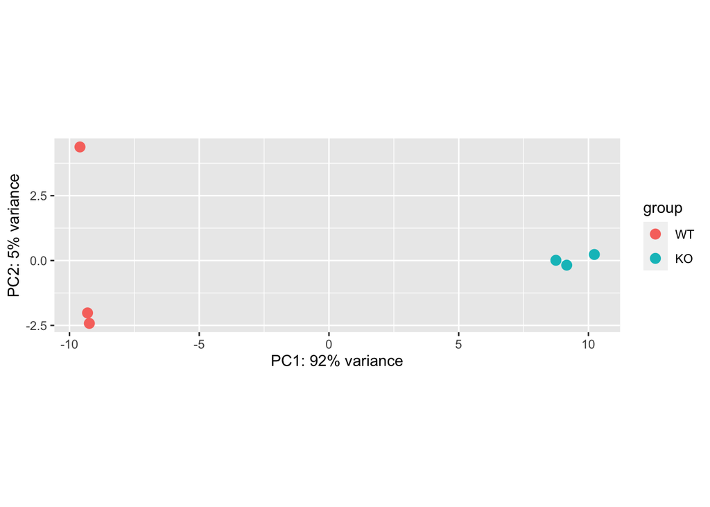

```r
vstcounts <- vst(dds, blind = FALSE)
plotPCA(vstcounts, intgroup=c("condition"))
```

It is also possible to customize the PCA plot using the *ggplot* function. Below we are adding shapes to represent the different days the samples were created.

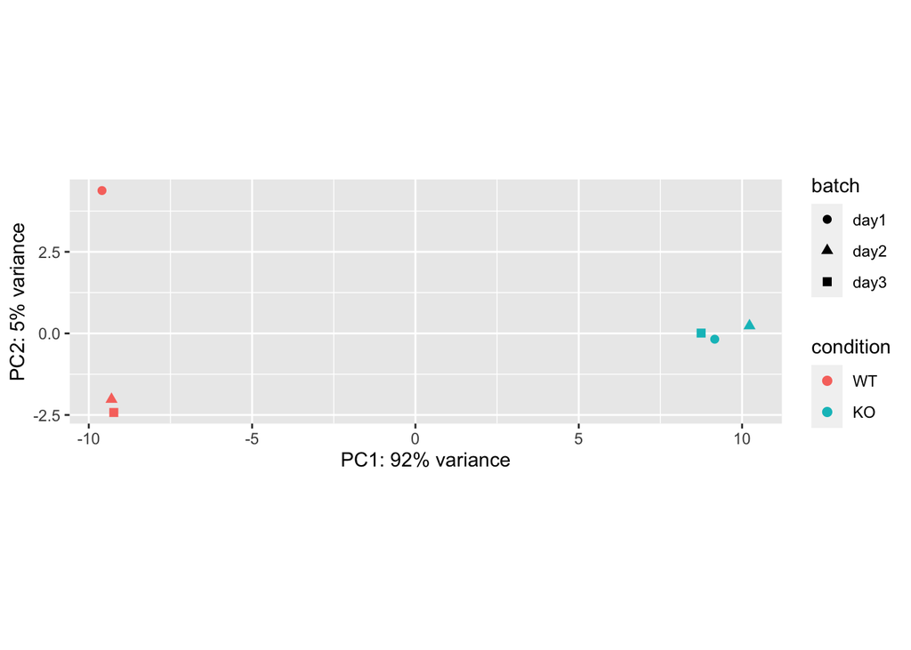

```r
pcaData <- plotPCA(vstcounts, intgroup=c("condition", "batch"), returnData=TRUE)
percentVar <- round(100 * attr(pcaData, "percentVar"))
ggplot(pcaData, aes(PC1, PC2, color=condition, shape=batch)) +
  geom_point(size=2) +
  xlab(paste0("PC1: ",percentVar[1],"% variance")) +
  ylab(paste0("PC2: ",percentVar[2],"% variance")) +
  coord_fixed()
```

Now, we are making sure the x and y axis are similar using `ylim` argument

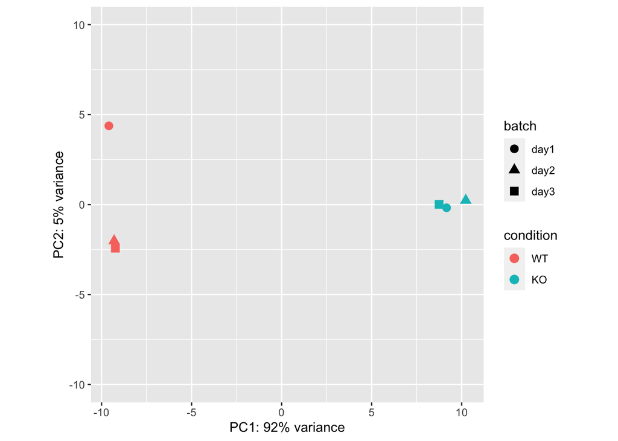

```r
pcaData <- plotPCA(vstcounts, intgroup=c("condition", "batch"), returnData=TRUE)
percentVar <- round(100 * attr(pcaData, "percentVar"))
ggplot(pcaData, aes(PC1, PC2, color=condition, shape=batch)) +
  geom_point(size=3) +
  ylim(-10,10) +
  xlab(paste0("PC1: ",percentVar[1],"% variance")) +
  ylab(paste0("PC2: ",percentVar[2],"% variance")) +
  coord_fixed()
```

Now that we got it looking the way we want it, we can take some time to interpret the plot. Each data point represents one sample. The x-axis typically PC1, explains the largest source of variation in the dataset. We can see that PC1 is primarily explained by knocking out the gene Tcf7 (encodes Tcf1) in CD8 T cells. The next largest source of variance within the dataset, or PC2, is explained by one sample created on day1 in the WT group. Overall, the groups are clustering as expected.

Finally, we can generate a correlation heatmap. This is a type of plot used to visualize the strength of relationships between samples.

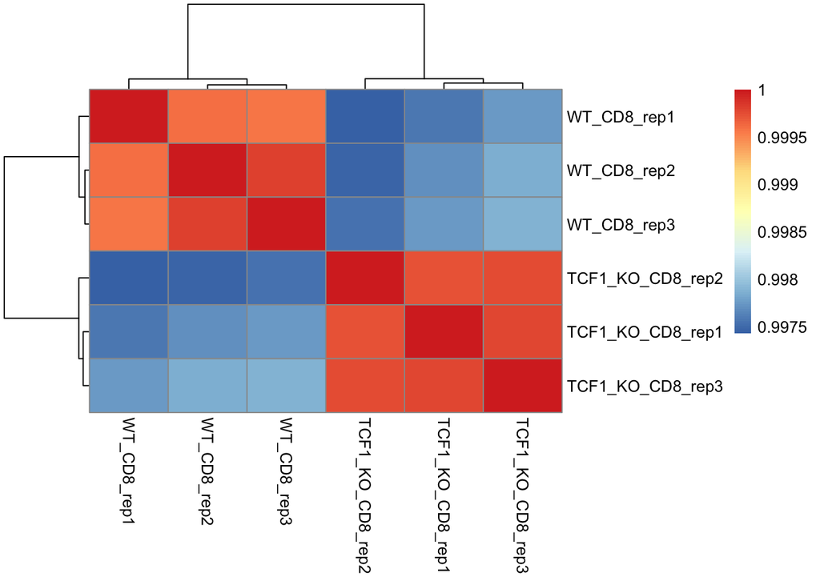

```r
library(pheatmap)
rld <- rlog(dds, blind=FALSE)
rld_mat <- assay(rld)
rld_cor <- cor(rld_mat)
pheatmap(rld_cor)
```

Using some arguments, we can make the plot look pretty

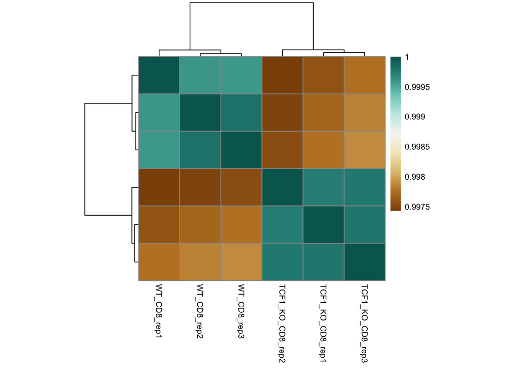

```r
pheatmap(rld_cor, clustering_distance_rows = "euclidean",
         fontsize = 8,  cellwidth = 40, show_rownames = F, color =
           colorRampPalette(brewer.pal(9,"BrBG"))(400))
```

### Citation

title: “Analyzing RNA-Seq with DESeq2” author: “Michael I. Love, Simon Anders, and Wolfgang Huber”

**Note:** if you use DESeq2 in published research, please cite:

> Love, M.I., Huber, W., Anders, S. (2014) Moderated estimation of fold change and dispersion for RNA-seq data with DESeq2. *Genome Biology*, **15**:550. 10.1186/s13059-014-0550-8